```python
import numpy as np
import pandas as pd
# standard
import time
import random
import re
from collections import Counter

# plots
import matplotlib.pyplot as plt
import plotly.express as px
import seaborn as sns
```

# Readability and Some Common features about the Philosophers

```python
from google.colab import drive
drive.mount("/content/drive")
```

```python
phil_data = pd.read_csv('/content/drive/MyDrive/5243/philosophy_data.csv')
```

The raw data is at https://www.kaggle.com/datasets/kouroshalizadeh/history-of-philosophy

I became interested in philosophy when I was in college. At the same time, I read some books on the history of philosophy and learned about the background and contributions of many famous philosophers. Among them, Aristotle and Plato impressed me the most. In this set of data, I was fortunate to see many famous quotes from them.

While looking at these famous philosophical quotes, I suddenly had an interesting thought: Who speaks the most philosophical quotes. I guess it should be Plato, because he started the famous Platonic school, and he can be regarded as one of the founders of philosophy.

### Qustion1: who speaks the most

```python
speak_most = phil_data.value_counts('author').reset_index().rename(columns = {0: 'counts'})
speak_most[:10]
```

|  | author | counts |
| --- | --- | --- |
| 0 | Aristotle | 48779 |
| 1 | Plato | 38366 |
| 2 | Hegel | 22700 |
| 3 | Foucault | 15240 |
| 4 | Heidegger | 15239 |
| 5 | Kant | 14128 |
| 6 | Nietzsche | 13548 |
| 7 | Marx | 13489 |
| 8 | Lewis | 13120 |
| 9 | Beauvoir | 13017 |

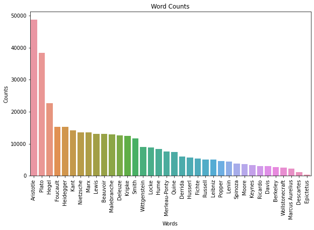

```python
plt.figure(figsize=(10,6))
sns.barplot(x=speak_most.author, y=speak_most.counts)
plt.xlabel("Words")
plt.ylabel("Counts")
plt.title("Word Counts")
plt.xticks(rotation=90)
plt.show()
```

Here we found that the top3 authors are Aristotle, Plato and Hegel. Another interesting question appeared: what are the most common words said by them? What words are they used to say?

### Q2: What are the most common words said by Aristotle, Plato, and Hegel

Here, I first removed stopwords and plot wordclouds of their quotes. Then, in order to see more clearly about which words they said the most, I plot a bar plot for each philosopher.

```python
from wordcloud import WordCloud, STOPWORDS, ImageColorGenerator
```

```python
phil_data.tokenized_txt = phil_data.tokenized_txt.apply(lambda x: re.sub("[\[\],?']",'', x).split())
```

```python
words = []
for word in phil_data.tokenized_txt:
  words += word

word_counts = Counter(words).most_common(150)

type(word_counts)
word = []
count = []
stopwords = set(STOPWORDS)
for wordcount in word_counts:
  if wordcount[0] not in stopwords:
    word.append(wordcount[0])
    count.append(wordcount[1])
```

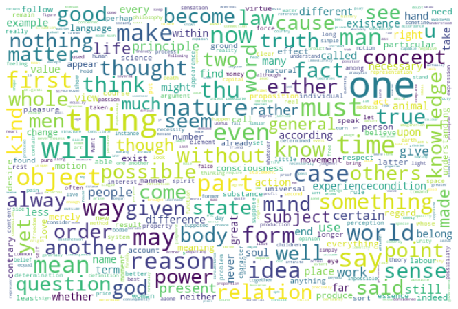

```python
t1 = time.time()
schools = phil_data.school.unique().tolist()

#df_temp = phil_data[phil_data.author == 'plato']
df_temp = phil_data

# render wordcloud
text = " ".join(txt for txt in df_temp.sentence_lowered)
wordcloud = WordCloud(stopwords=stopwords, max_font_size=50, max_words=500,
                      width = 600, height = 400,
                      background_color="white").generate(text)
plt.figure(figsize=(12,8))
plt.imshow(wordcloud, interpolation="bilinear")
plt.axis("off")
plt.show()
t2 = time.time()
```

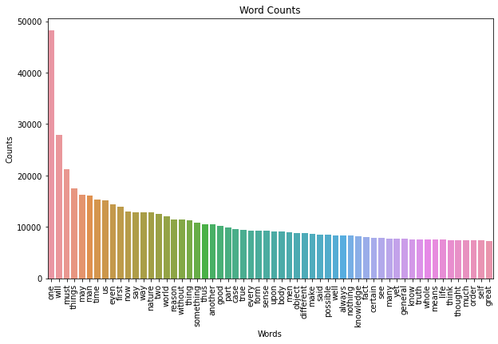

```python
import seaborn as sns
plt.figure(figsize=(10,6))
sns.barplot(x=word, y=count)
plt.xlabel("Words")
plt.ylabel("Counts")
plt.title("Word Counts")
plt.xticks(rotation=90)
plt.show()
```

```python
Plato = phil_data[phil_data.author == 'Plato']
```

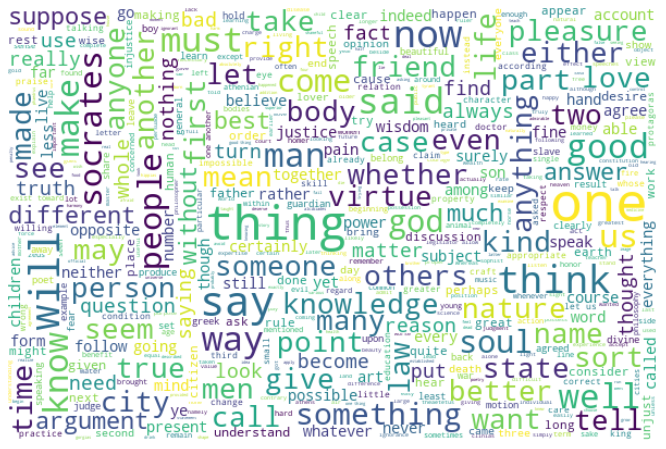

```python
t1 = time.time()
schools = phil_data.school.unique().tolist()

#df_temp = phil_data

# render wordcloud
text = " ".join(txt for txt in Plato.sentence_lowered)
wordcloud = WordCloud(stopwords=stopwords, max_font_size=50, max_words=500,
                      width = 600, height = 400,
                      background_color="white").generate(text)
plt.figure(figsize=(12,8))
plt.imshow(wordcloud, interpolation="bilinear")
plt.axis("off")
plt.show()
t2 = time.time()
```

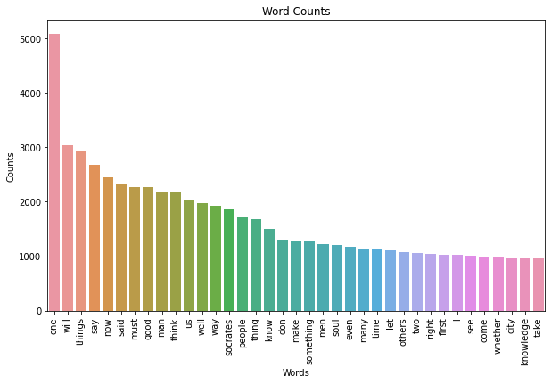

```python
words = []
for word in Plato.tokenized_txt:
  words += word

word_counts = Counter(words).most_common(120)
type(word_counts)
word = []
count = []
stopwords = set(STOPWORDS)
for wordcount in word_counts:
  if wordcount[0] not in stopwords:
    word.append(wordcount[0])
    count.append(wordcount[1])

plt.figure(figsize=(10,6))
sns.barplot(x=word, y=count)
plt.xlabel("Words")
plt.ylabel("Counts")
plt.title("Word Counts")
plt.xticks(rotation=90)
plt.show()
```

```python
Aristotle = phil_data[phil_data.author == 'Aristotle']
```

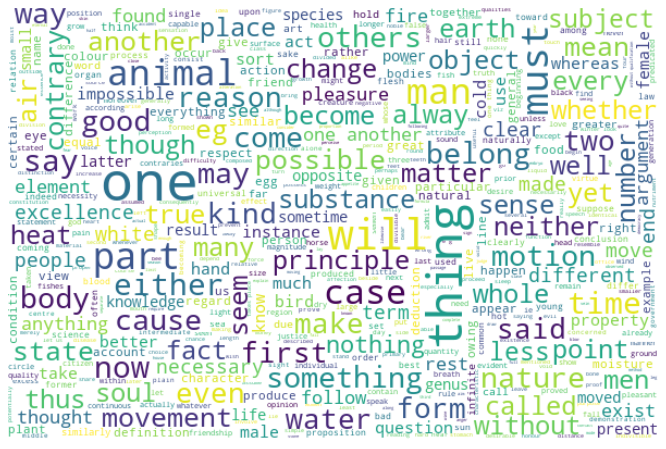

```python
t1 = time.time()
schools = phil_data.school.unique().tolist()

#df_temp = phil_data

# render wordcloud
text = " ".join(txt for txt in Aristotle.sentence_lowered)
wordcloud = WordCloud(stopwords=stopwords, max_font_size=50, max_words=500,
                      width = 600, height = 400,
                      background_color="white").generate(text)
plt.figure(figsize=(12,8))
plt.imshow(wordcloud, interpolation="bilinear")
plt.axis("off")
plt.show()
t2 = time.time()
```

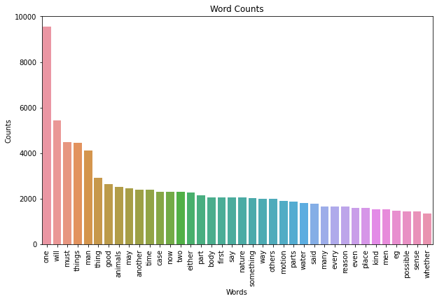

```python
words = []
for word in Aristotle.tokenized_txt:
  words += word

word_counts = Counter(words).most_common(120)
type(word_counts)
word = []
count = []
stopwords = set(STOPWORDS)
for wordcount in word_counts:
  if wordcount[0] not in stopwords:
    word.append(wordcount[0])
    count.append(wordcount[1])

plt.figure(figsize=(10,6))
sns.barplot(x=word, y=count)
plt.xlabel("Words")
plt.ylabel("Counts")
plt.title("Word Counts")
plt.xticks(rotation=90)
plt.show()
```

Both Plato and Aristotle like to say One, Things, Will. It seems that Plato was still greatly influenced by Aristotle.

```python
Hegel = phil_data[phil_data.author == 'Hegel']
```

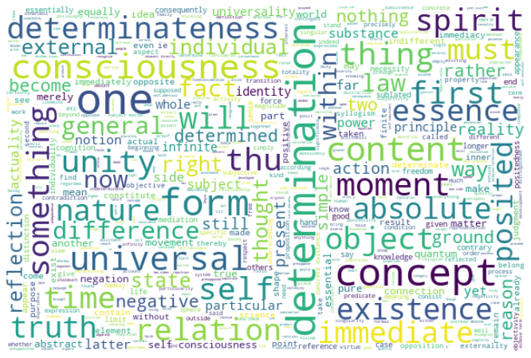

```python
t1 = time.time()
schools = phil_data.school.unique().tolist()

#df_temp = phil_data

# render wordcloud
text = " ".join(txt for txt in Hegel.sentence_lowered)
wordcloud = WordCloud(stopwords=stopwords, max_font_size=50, max_words=500,
                      width = 600, height = 400,
                      background_color="white").generate(text)
plt.figure(figsize=(12,8))
plt.imshow(wordcloud, interpolation="bilinear")
plt.axis("off")
plt.show()
t2 = time.time()
```

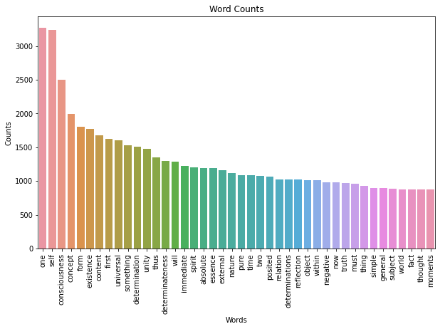

```python
words = []
for word in Hegel.tokenized_txt:
  words += word

word_counts = Counter(words).most_common(100)
type(word_counts)
word = []
count = []
stopwords = set(STOPWORDS)
for wordcount in word_counts:
  if wordcount[0] not in stopwords:
    word.append(wordcount[0])
    count.append(wordcount[1])

plt.figure(figsize=(10,6))
sns.barplot(x=word, y=count)
plt.xlabel("Words")
plt.ylabel("Counts")
plt.title("Word Counts")
plt.xticks(rotation=90)
plt.show()
```

### Q3: Who like to speak long sentance?

```python
long_sen = phil_data.groupby(by = ['author']).mean().drop(columns = ['original_publication_date','corpus_edition_date'])
long_sen = long_sen.sort_values(by = 'sentence_length',ascending = False)[:40]
long_sen.reset_index(inplace = True)
```

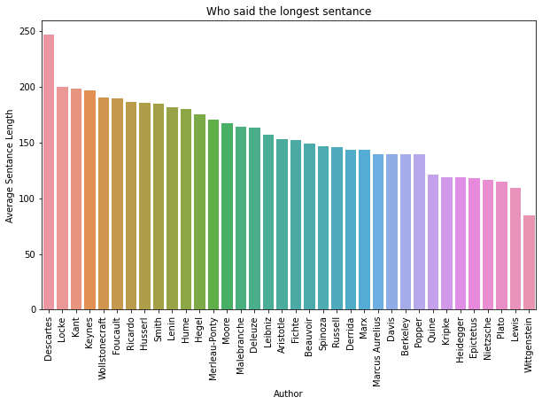

```python
plt.figure(figsize=(10,6))
sns.barplot(x= long_sen['author'], y=long_sen['sentence_length'])
plt.xlabel("Author")
plt.ylabel("Average Sentance Length")
plt.title("Who said the longest sentance")
plt.xticks(rotation=90)
plt.show()
```

```python
from operator import index
authors = ['Hegel','Aristotle', 'Plato']
index_list = long_sen[long_sen['author'].isin(authors)].index.tolist()
print('Here are the ranks of Hegal, Aristotle, Plato',index_list)
```

```
Here are the ranks of Hegal, Aristotle, Plato [11, 17, 33]
```

Here we can see Hegel likes to speak long sentances than Aristotle and Plato. As for me, long philosphy sentances are usally more difficult to understand, especially when they contains a plenty of difficult words. Let's see whose sentances are the most diffcult to be understanded.

### Q4: Readability VS Length

```python
!pip install textstat
import textstat
```

```
     ━━━━━━━━━━━━━━━━━━━━━━━━━━━━━━━━━━━━━━━ 105.1/105.1 KB 4.4 MB/s eta 0:00:00
     ━━━━━━━━━━━━━━━━━━━━━━━━━━━━━━━━━━━━━━━━ 2.0/2.0 MB 33.6 MB/s eta 0:00:00
```

```python
phil_data['readability_score'] = phil_data.sentence_lowered.apply(lambda x : textstat.flesch_reading_ease(x))
```

```python
score = phil_data.groupby(by = ['author']).mean().drop(columns = ['original_publication_date','corpus_edition_date'])
readability_score = score.sort_values('readability_score').reset_index()
readability_score[:3]
```

|  | author | sentence_length | readability_score |
| --- | --- | --- | --- |
| 0 | Husserl | 185.473703 | 35.869110 |
| 1 | Kant | 198.159400 | 38.872220 |
| 2 | Keynes | 196.654060 | 40.330868 |

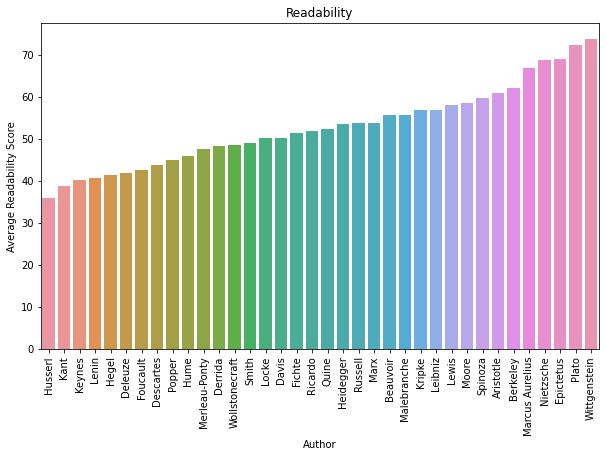

```python
plt.figure(figsize=(10,6))
sns.barplot(x= readability_score['author'], y=readability_score['readability_score'])
plt.xlabel("Author")
plt.ylabel("Average Readability Score")
plt.title("Readability")
plt.xticks(rotation=90)
plt.show()
```

**Here, larger readability score means easier to read.** So as we can see, the readability score rank for the 3 philosophers are Plato > Aristotle > Hegel. Plato's quotes are one of the most readable, and Hegel's are one of the most difficult to read.

Is there a relation between the average length and readability of the quotes?

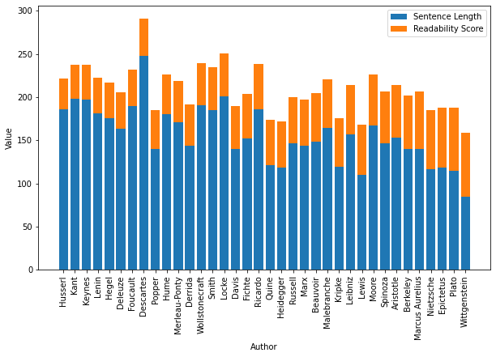

```python
import matplotlib.pyplot as plt
x = readability_score['author']
y1 = readability_score['sentence_length']
y2 = readability_score['readability_score']

# Create the bar plot
fig, ax = plt.subplots(figsize=(10,6))
ax.bar(x, y1, label='Sentence Length')
ax.bar(x, y2, bottom=y1, label='Readability Score')

# Add axis labels and legend
ax.set_xlabel('Author')
ax.set_ylabel('Value')
ax.legend()
plt.xticks(rotation=90)
# Show the plot
plt.show()
```

The barplot shows the average sentance length and readability score. It looks like there is a trend that larger average sentance length result in lower readability score(more difficult to read). To learn more about the relation between length and readability, a scatter plot may help.

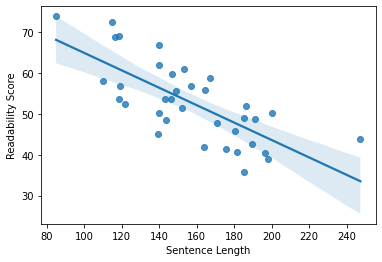

```python
sns.regplot(x='sentence_length', y='readability_score', data=readability_score)
plt.xlabel('Sentence Length')
plt.ylabel('Readability Score')
plt.show()
```

# Summary

In summary, longer sentance tends to be more difficult to read. For Aristotle, Plaoto, Hegel, who speak the most quotes, Plato's quotes are kind of easier to read, and they are also shorter than the other two philosophers. So, if you are interested in philosophy and want to start learning, Plats's quotes might be a good choice!